# ESD(T) - Course Information

Embedded System - STM32

2024 Autumn

WU Xiaokun 吴晓堃

xkun.wu [at] gmail

| Computer Science - UG3 |  |
| --- | --- |
| Course | Embedded System Development |
| Term | 2024 Autumn |
| Final | Project |
| Credits | WU Xiaokun 吴晓堃 |

| 计算机科学专业必修课 |  |
| --- | --- |
| 课程名称 | 嵌入式系统开发实践 |
| 授课时间 | 2024年秋 |
| 考试形式 | 实践项目 |
| 学分 | 吴晓堃 |

# Course Information

#### Short Intro

This course provides practical tutorials for Embedded System Development, based on `STM32` micro-controller from `STMicroelectronics`.

#### Prerequisites

We expect you to have the following skills before taking this course:

**Required**：

- Digital and Analog Circuit
- C programming language

**Recommended**：

- Electronic Design

#### Teaching Plan

We organize this course into a 4-week session (8 hours per week). The main contents are listed below:

Topology

Task

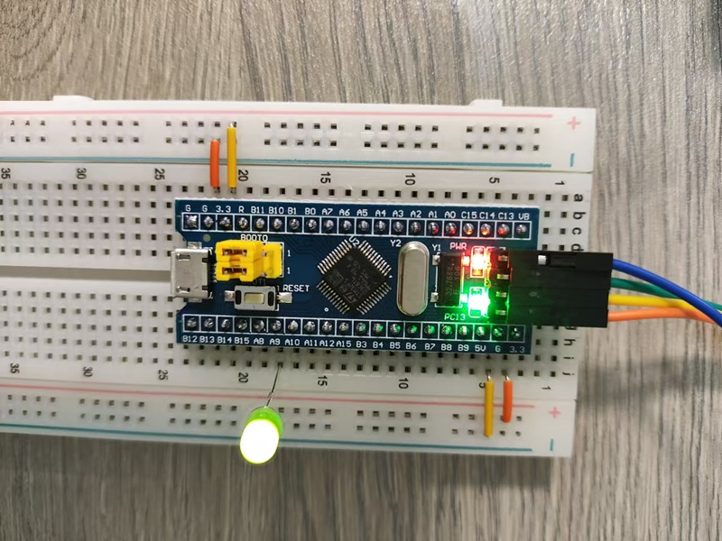

GPIO - flashing led

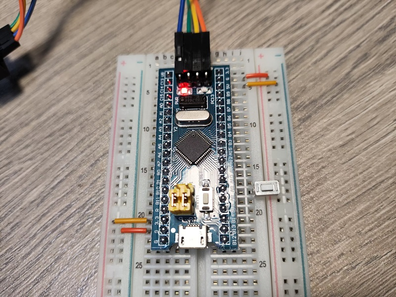

GPIO - button

[video not shown]

GPIO - rocking led

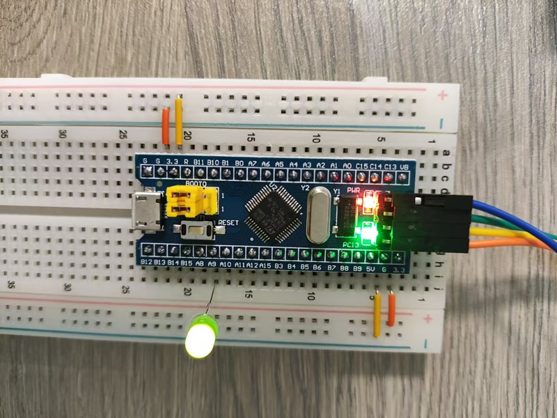

Clock tree - high speed external resonator

[figure not shown]

UART - simple serial transmission

[figure not shown]

SPI - external flash (W25Q64)

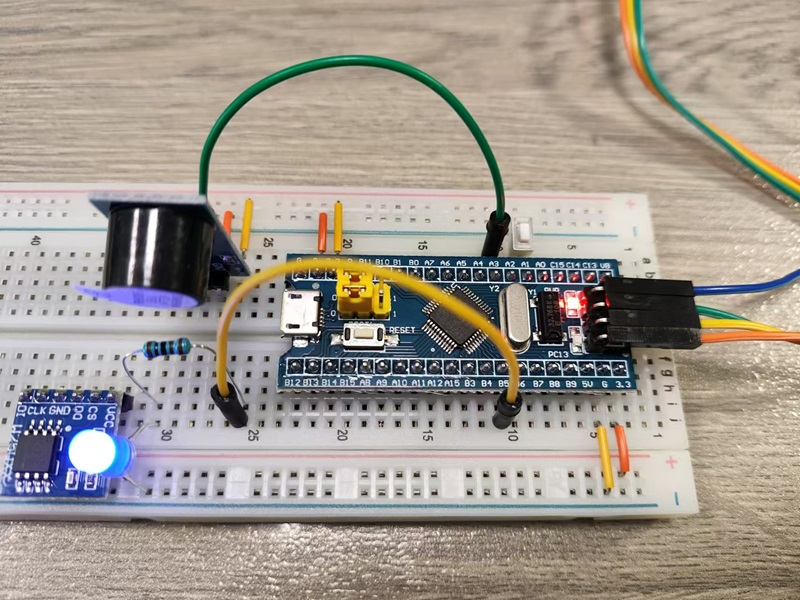

Interrupt - buzzer

[figure not shown]

I2C - text on OLED (SSD1306, 128x64 Dot Matrix)

[video not shown]

Timer - breathing led

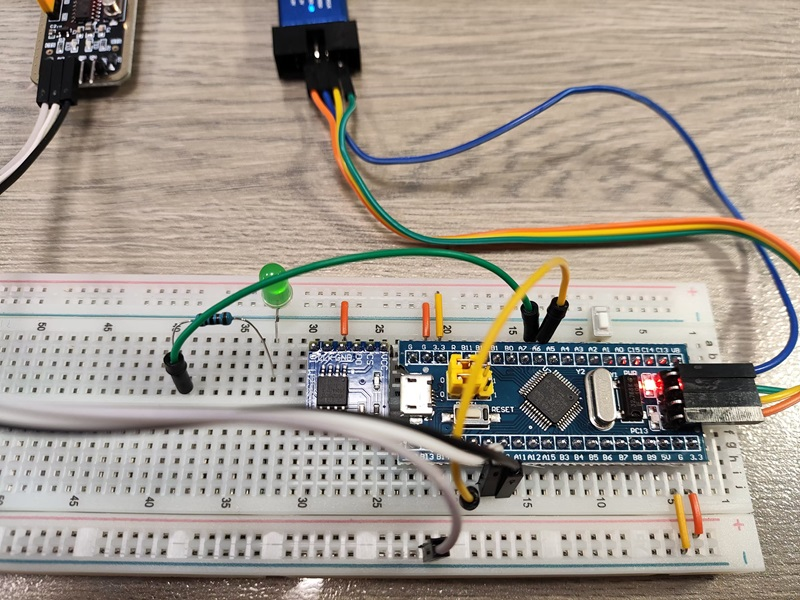

Timer - measure PWM and print via UART

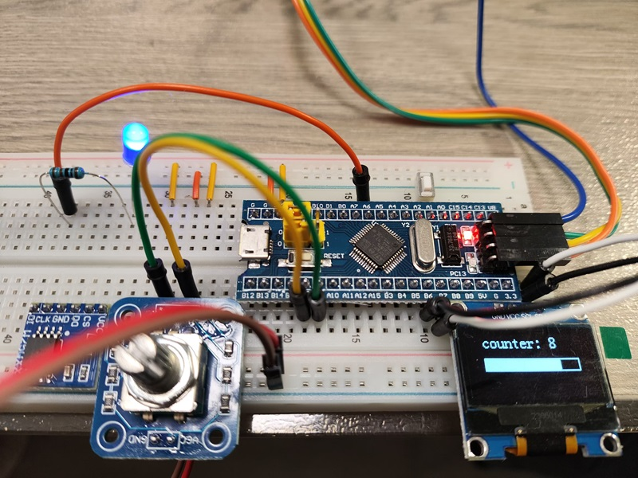

Timer - encoder with a control knob

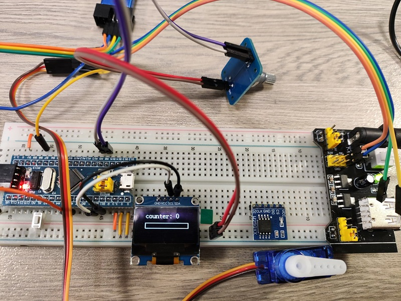

Timer - servo

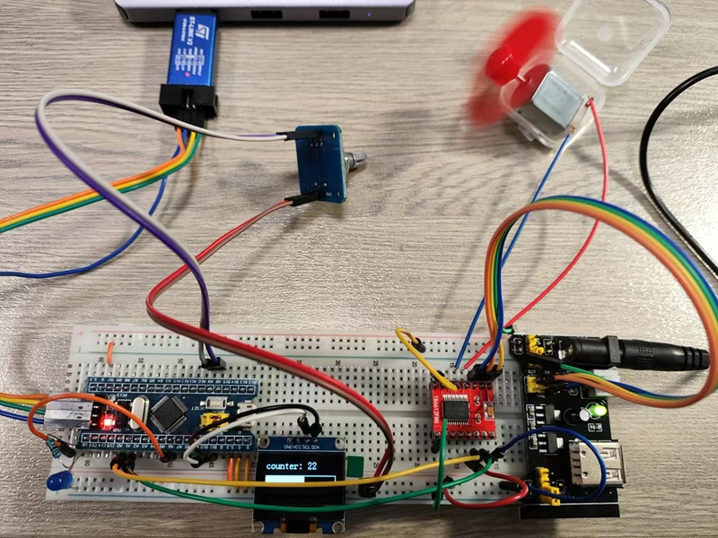

Timer - motor (TB6612FNG)

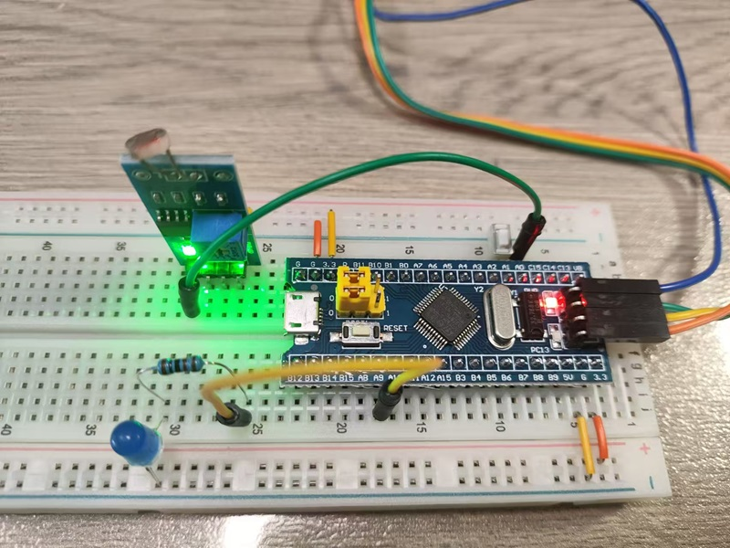

ADC - photosensitive sensor

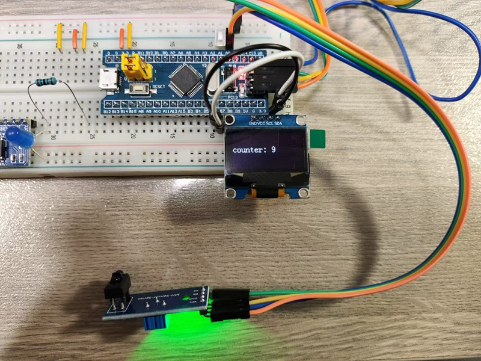

ADC - infrared sensor

#### Project

We try to build a 2-wheel self-balancing car from scratch by the end of this tutorial session.

Topology

Task

[video not shown]

Prototype - wheel speed control via PWM

[video not shown]

Prototype.parameters - stand on a soft surface (higher friction is better)

[video not shown]

Prototype.parameters - reduce high/low-frequency oscillations

[video not shown]

Prototype.parameters - resistant to external force

[video not shown]

Prototype.parameters - stand on a hard surface

[video not shown]

Prototype.parameters - being able to recover from falling down

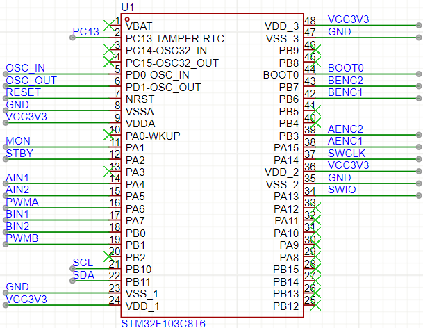

EDA - draw schematics

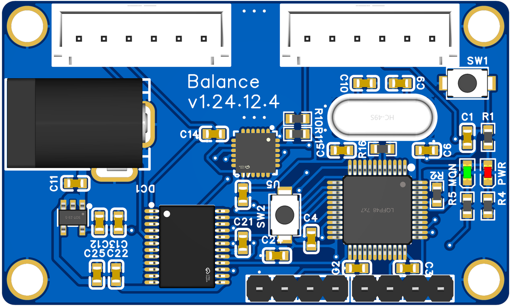

EDA - design PCB layout

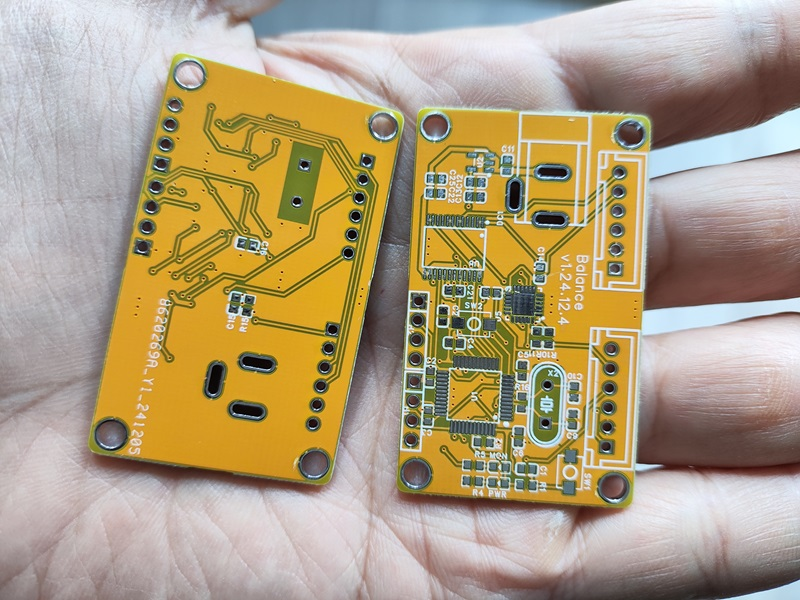

EDA - print PCB

#### Methodology

Problem-solving-oriented, with a primary emphasis on practical skills.

以解决实际问题为导向，主要强调实践技能。

#### Evaluation

- Attendance & participation: 10%
- Practical exercises: 40%
- Final project: 50%

#### Resource

- 嘉立创EDA在线编辑器[^1]
[^1]: https://pro.lceda.cn/editor